# Example of an outbreak investigation report

**Learning objectives**

The student should be able to reproduce the basic descriptive analysis section of an outbreak or surveillance report. Here is a sample outbreak report (“Guidelines for writing outbreak investigation reports” shared by Dr. Kostas Danis on October, 6, 2023). The student will be engaged in complete the Results section.

**Learning Objectives**

- basic table creation (both tibble/tribble and gt)

```r
tbl_header <- tribble(
  ~colnames               , ~content,
  "**Date:**"             , "25 September 1996",
  "**To:**"               , "Director of Public Health, Eastern Health Board",
  "**From:**"             , "Thomas Grein, EPIET Fellow, EHB",
  "**Supervisor:**"       , "Darina O'Flanagan",
  "**Subject:**"          , "Salmonella typhimurium outbreak",
  "**Location:**"         , "Malahide, Country Fingal",
  "**Date of Departure:**", "N/A",
  "**Date of return:**"   , "N/A",
) |>
  gt() |>
  gt_theme_ecdc() |>
  tab_style(
    style = cell_text(color = "darkgreen", weight = "bold"),
    locations = cells_body("colnames")
  ) |>
  tab_options(column_labels.hidden = TRUE)

tbl_header
```

**1**

Define a `tibble` table in a “natural” way by rows.

| **Date:** | 25 September 1996 |
| --- | --- |
| **To:** | Director of Public Health, Eastern Health Board |
| **From:** | Thomas Grein, EPIET Fellow, EHB |
| **Supervisor:** | Darina O’Flanagan |
| **Subject:** | Salmonella typhimurium outbreak |
| **Location:** | Malahide, Country Fingal |
| **Date of Departure:** | N/A |
| **Date of return:** | N/A |

**Learning Objectives**

- save tables on disk as images

```r
gtsave(data = tbl_header, filename = here("output/tbl_header.png"))
```

## Analyses

### Import, clean, and manage data

**Learning Objectives**

- import (`here` and `import`)
- clean (janitor)
- data management (`mutate` and `select`)

> Here we could add additional “exercices” making the imported data more tricky to tidy (i.e., missing data, multiple column names, ….).

```r
random_wedding <- import(here("data-raw/random_wedding.csv")) |>
  clean_names() |>
  remove_empty(c("rows", "cols")) |>
  as_tibble() |>
  mutate(
    age_class = case_when(
      age >=  5 & age <= 14 ~ " 5 - 14",
      age >= 15 & age <= 44 ~ "15 - 44",
      age >= 45 & age <= 64 ~ "45 - 64",
      age >= 65 ~ "65+",
      TRUE ~ NA_character_
    ),
    .after = age
  ) |>
  select(-age) |>
  mutate(
    seating_arrangements = seating_arrangements |>
      factor(levels = paste("Table", 1:12))
  ) |>
  mutate(
    meals = main_meal_only |>
      if_else(
        true = "Main meal only",
        false = "Late night meal only"
      ) |>
      factor(),
    .after = main_meal_only
  ) |>
  select(-main_meal_only) |>
  set_variable_labels(
    guest_id = "Guest id",
    wedding_cohort = "Wedding cohort",
    eligible = "Eligible",
    interviewed = "Interviewed",
    not_eaten = "Not eaten",
    refused_to_participate = "Refused to participate",
    unable_to_locate = "Unable to locate",
    age_class = "Age class",
    gender = "Gender",
    illness = "Illness",
    meals = "Meals",
    date_of_illness = "Date of illness",
    seating_arrangements = "Seating arrangements"
  )

random_labs <- import(here("data-raw/random_labs.csv")) |>
  clean_names() |>
  remove_empty(c("rows", "cols")) |>
  as_tibble() |>
  set_variable_labels(
    guest_id = "Guest id",
    diarrhoea = "Diarrhoea",
    feeling_faverish = "Feeling faverish",
    aches_and_pains = "Aches and pains",
    nausea = "Nausea",
    abdominal_cramps = "Abdominal cramps",
    vomiting = "Vomiting",
    headaches = "Headaches",
    blood_seen_in_on_stool = "Blood seen in / on stool",
    gp_visit = "Gp visit",
    hospitalization = "Hospitalization",
    stool_samples_obtained = "Stool samples obtained",
    stool_sample_plus_ve_for_salmonella_typhimurium =
      "Stool sample +ve for salmonella typhimurium",
    time_in_hospital = "Time in hospital",
    duration_of_illness = "Duration of illness",
    incubation_period = "Incubation period"
  )
```

### Compute tables

**Learning Objectives**

- `gt_summary::tbl_summary()`

```r
tbl_one <- random_wedding |>
  tbl_summary(
    include = c(
      wedding_cohort, eligible, refused_to_participate,
      unable_to_locate, interviewed
    )
  ) |>
  modify_header(label = "") |>
  bold_labels() |>
  add_n()

# inlines repetitive informations from tbl-one
cohort_ss <- inline_text(tbl_one, variable = wedding_cohort, column = "n")
```

```r
tbl_two <- random_wedding |>
  tbl_summary(
    include = c(age_class, gender),
    type = gender ~ "dichotomous",
    value = list(gender = "Female"),
    label = gender ~ "Female"
  ) |>
  modify_header(label = "") |>
  bold_labels() |>
  add_n()
```

Table three is way too difficult in this shape; we need to investigate for a cleaner solutions!

**Learning Objectives**

- `gt_summary::tbl_uvregression()`
- `gt_summary::tbl_merge()`

```r
tbl_rr <- random_wedding |>
  select(
    gender, age_class, meals, seating_arrangements, illness
  ) |>
  tbl_uvregression(
    method = glm, method.args = list(family = binomial(link = "log")),
    y = illness,
    exponentiate = TRUE,
  )

tbl_ar <- c("gender", "age_class", "meals", "seating_arrangements", "illness") |>
  map(~tbl_attack_rate(random_wedding, .x)) |>
  tbl_stack()

var_considered <- tbl_rr$table_body |>
  select(tbl_id1, variable, var_label) |>
  distinct()

tbl_ar$table_body <- tbl_ar$table_body |>
  rowwise() |>
  mutate(
    variable = var_considered[.data[["tbl_id1"]], "variable"] |>
      as.character(),
    var_label = var_considered[.data[["tbl_id1"]], "var_label"] |>
      as.character(),
    row_type = if_else(
      .data[["label"]] %in%
        c(
          "Gender", "Age class", "Meals", "Seating arrangements",
          "Illness"
        ),
      .data[["row_type"]],
      "level"
    )
  )

tbl_three <- list(tbl_ar, tbl_rr) |>
  tbl_merge(tab_spanner = c("Attack Rate", "Relative Risks")) |>
  modify_header(label = "") |>
  bold_labels()
```

**1**

This is needed because in the `tbl_ar` variables’ levels are treated as variable *per se*, i.e. not as level; we need to recreate the var/levels hierarchy in the table, and we can take that from the `tbl_rr`.

**2**

We look at each row independently to substitute the relevant table field using the `tbl_rr` corresponding ones.

```r
tbl_four <- random_labs |>
  tbl_summary(
    include = -c(
      guest_id, time_in_hospital, duration_of_illness, incubation_period
    )
  ) |>
  # Every variable count *per se*, but we like to group all Symptoms.
  modify_table_body(
    mutate,
    groupname_col = case_when(
      variable %in% c("diarrhoea", "feeling_faverish", "aches_and_pains", "nausea", "abdominal_cramps", "vomiting", "headaches", "blood_seen_in_on_stool") ~ "Symptoms",
      variable %in% c("gp_visit", "hospitalization") ~ "Other clinical",
      TRUE ~ "Laboratory"
    )
  ) |>
  modify_header(groupname_col = "") |>
  bold_labels()
```

**1**

This is a usefull pattern to add grouping variable. Another one is to create a summary per group and then stack together the table. See [this](https://stackoverflow.com/a/65668806/4434088) post.

```r
tbl_five <- random_labs |>
  tbl_summary(
    include = c(
      time_in_hospital, duration_of_illness, incubation_period
    )
  ) |>
  modify_header(label = "") |>
  bold_labels()
```

```r
gtsave(data = as_gt(tbl_one), filename = here("output/tbl_one.png"))
gtsave(data = as_gt(tbl_two), filename = here("output/tbl_two.png"))
gtsave(data = as_gt(tbl_three), filename = here("output/tbl_three.png"))
gtsave(data = as_gt(tbl_four), filename = here("output/tbl_four.png"))
gtsave(data = as_gt(tbl_five), filename = here("output/tbl_five.png"))
```

### Compute figures

**Learning Objectives**

- data management (`filter`)
- `ggplot` (and `geom_histogram()`, and `labs`)

```r
fig_one_simple <- random_wedding |>
  left_join(random_labs) |>
  filter(diarrhoea & illness) |>
  ggplot(aes(date_of_illness)) +
  geom_histogram(
    breaks = seq(
      from = ymd_hm("1996-08-21 00:00"),
      to = ymd_hm("1996-08-25 23:59"),
      by = 3600*6
    ),
    closed = "left",
    fill = "yellow",     # color of lines around bars
    colour = "black"
  ) +
  scale_x_datetime(
    labels = label_date_short(format = c("", "%B", "%d", "%H")),
    breaks = breaks_width("6 hours"),
    limits = c(ymd_hm("1996-08-21 00:00"), ymd_hm("1996-08-25 23:59")),
    expand = c(0, 0)
  ) +
  scale_y_continuous(expand = c(0, 0)) +
  labs(
    x = "Date and time of onset",
    y = "Cases (N)"
  ) +
  theme_minimal()
```

**1**

Simple solution, but not exactly the same as in the guidelines, i.e. it is composed by bars and not by unit-tiles

**2**

Theming will be showed but not teached deeply in the details of time formats, code will be provided as an example template

**Learning Objectives**

- managing dates (`lubridate`)

```r
fig_one <- random_wedding |>
  left_join(random_labs) |>
  filter(diarrhoea & illness) |>
  mutate(
    intervals = date_of_illness |>
      cut(
        breaks = seq(
          from = ymd_h("1996-08-21 00"),
          to = ymd_h("1996-08-26 3"),
          by = "6 hours"
        ),
        labels = FALSE,
        include.lowest - TRUE
      )
  ) |>
  mutate(
    # midpoint
    x = ymd_h("1996-08-21 00") + hours((intervals - 1) * 6 + 3),
    # tile stack
    y = row_number(),
    .by = intervals
  ) |>
  ggplot(aes(x = x, y = y)) +
  geom_tile(fill = "yellow", colour = "black", width = 6*3600, height = 1) +
  scale_x_datetime(
    labels = label_date_short(format = c("", "%B", "%d", "%H")),
    breaks = breaks_width("6 hours"),
    limits = c(ymd_h("1996-08-21 00"), ymd_h("1996-08-26 3")),
    expand = c(0, 0)
  ) +
  scale_y_continuous(
    minor_breaks = NULL,
    expand = c(0, 0)
  ) +
  coord_equal(3600 * 6) +
  labs(
    x = "Date and time of onset",
    y = "Cases (N)"
  ) +
  theme_minimal()
```

**1**

This is a more complex graph that reproduce more as-is the prototype graph. The added skills to learn are: `cut` variables into intervals (keeping intervals progressive number only), slide timepoints to a midrange position, produce progressive id by levels of a variable (using `mutate(..., .by = ...)`), and use `geom_tile()`

**Learning Objectives**

- save plots on disk

```r
ggsave(
  filename = here("output/fig_one_simple.png"),
  plot = fig_one_simple
)
ggsave(
  filename = here("output/fig_one.png"),
  plot = fig_one
)
```

**1**

For plots, ggsave require the path as first argument

**2**

Note: if `plot` is not provided, it will be saved the last printed one

## Abstract

On 26 August 1996 the Eastern Health Board (EHB) was informed of an outbreak of gastrointestinal illness among guests of a wedding party that was held in a large hotel in Malahide on 21 August 1996.

Many guests had fallen ill since the reception and some had required hospitalisation. Malahide is a popular seaside town approximately twenty kilometres north of Dublin City.

The same day the EHB started an investigation to assess the extent of the outbreak, identify the mode and the vehicle of transmission, and initiate appropriate control measures.

Dr. Darina O’Flanagan, Specialist in Public Health Medicine at the EHB, led the epidemiological investigations. She was assisted by Dr. Thomas Grein, Fellow of the European Programme for Intervention Epidemiology Training. Mr. Tom McCarthy, Principal Environmental Health Officer for food hygiene North Dublin City with special responsibility for communicable disease, and Mr. Derek Bauer, Principal Environmental Health Officer for County Fingal, led the environmental investigations and supervised the implementation of control measures.

## Materials and Methods

### Case definition

We defined a case as a person who had consumed food at the wedding reception on 21 August 1996 and developed diarrhoea (three or more loose stools in 24 hours) within the next 72 hours.

### Case Finding

**Learning Objectives**

- just look hot to embed code in the text, and how to inject tabels’ cells values directly on in.

We obtained the addresses and telephone numbers of all 127 attendees of the wedding reception. Hotel management provided a copy of the menu and a list of all food items served during the reception.

Starting 27 August 1996, Environmental Health Officers (EHOs) conducted personal interviews at the homes of all wedding guests. Hospitalised cases were interviewed after discharge from hospital. Information was obtained on demographic details, symptoms of gastrointestinal illness three days prior to and after the wedding reception, the time of onset and the duration of symptoms, contact with ill persons not related to the wedding party, secondary spread among family members, foods consumed during the reception, whether the family doctor was contacted because of the illness, whether hospitalisation was required, and length of hospital stay if admitted.

### Analytical study design

We conducted a retrospective cohort study to identify the potential vehicle of the outbreak. The retrospective cohort design was chosen because information could be obtained on a clearly identifiable risk group.

Definition of exposure. The outbreak occurred among 127 guests who attended the wedding reception in the hotel on 21 August 1996. The main meal was served to 108 guests at 1800 hours on 21 August 1996. The meal consisted of honeydew melon, roast turkey, baked Irish gammon (ham steak), a selection of vegetables and potatoes, and chocolate eclairs for dessert. At 2200 hours sandwiches (turkey, ham, chicken, salad, savoury, egg, cheese) were offered to the guests and consumed by 58 individuals. Hotel staff prepared all dishes and sandwiches in a kitchen on the premises except for a home-made birthday cake and a home-made wedding cake. Both cakes were brought into the hotel by guests and consumed throughout the evening. To identify potential risk factors for illness, all guests were asked if they had consumed any of these food items

The restaurant of the hotel caters for hotel guests and a large number of visitors. No other functions were held on the day of the wedding reception. The number of persons who attended the restaurant on 21 August 1996 is unknown.

Analysis of the data was performed with Epi Info software, version 6.041. Food specific attack rates (AR), relative risks (RR) and 95% confidence intervals (95% CI) were calculated for the consumption of food items. The c2 test was used to compare proportions between groups.

### Laboratory investigations

All interviewed persons who reported an illness were asked to provide a stool sample. Stool samples were also collected from some individuals who attended the wedding reception but did not become ill. Most specimens from non-cases were obtained from household members of cases. All specimens were submitted to the Public Health Laboratory for culture. Faecal specimens were also obtained from the 17 kitchen workers who were on duty during the week of the wedding reception, regardless of their symptoms.

### Environmental investigations

Starting 26 August, EHOs inspected the restaurant and the hotel kitchen on several occasions, investigated food handling practices and interviewed all food handlers for illness one week prior to and after the wedding. They examined transport, storage and preparation processes for the foods served at the wedding reception, and reviewed order and delivery books of the restaurant. The ingredients of incriminated foods were identified and traced to their sources.

Food specimens from the day of the wedding were no longer available when investigations commenced. EHOs sampled the same type of food items which were mentioned on the wedding reception menu and submitted them for culture on 27 August 1996.

## Results

### Descriptive findings

For seven food items, cases had higher attack rates than non-cases: turkey (RR ¥), savoury sandwich (RR 1.85), birthday cake (RR 1.61), egg sandwich (RR 1.56), chicken sandwich (RR 1.43), ham (RR 1.22) and turkey sandwich (RR 1.12).

### Environmental investigations

EHOs noted 23 violations of the food hygiene regulations during the kitchen inspections. Relevant findings with regard to the wedding outbreak were that frozen food was thawed in hot water, cooked meats cooled down at room temperature for indeterminate times and that storage practices in the cold room allowed for possible cross-contamination of raw meat.

Food items from hotel kitchen and bar buffet were sent to the laboratory on 27 August 1996. The only positive microbiological finding was found for a sample of cooked turkey (Salmonella agona).

The examination of the kitchen delivery dockets revealed that ten turkeys were delivered to the hotel on 19 August. Six of the ten turkeys were used for the wedding reception. Each of them weighted 20-24 lb. and were cooked on 20 August at 250oC for thirty minutes and at 180oC for two and a half hours. After cooking they were put into a non-refrigerated holding cabinet, left at room temperature to cool down, and later removed to the cold room. We could not determine how long the turkeys were left in the non-refrigerated holding cabinet. Other turkeys, cooked at midday on 21 August, were left overnight in the holding cabinet before being removed to the cold room.

Seventeen kitchen workers were interviewed and stool samples obtained from them. None reported an illness but eight (47%) stool samples were culture positive for S. typhimurium. Antibiotic resistance was determined for some isolates and matched that of the cases (resistant to Ampicillin, Amoxycillin, Chloramphenicol, Sulphonamides).

## Discussion

The primary objectives of our study were to identify the mode of transmission, the vehicle of the outbreak and to initiate appropriate control measures. Our data suggest that the vehicle of the outbreak was turkey served during the wedding reception on 21 August, and the infecting agent S. typhimurium DT104.

The environmental investigations support our epidemiological findings and revealed severe deficiencies in food handling practices in the hotel kitchen. Stool samples from eight of the 17 kitchen staff on duty during the week of the outbreak were also positive for S. typhimurium suggesting that the infective food was prepared and consumed in the hotel kitchen.

Our findings are consistent with other foodborne outbreaks related to the consumption of turkey. It is also a biologically plausible vehicle for the aetiological agent, S. typhimurium. The implicated exposure preceded illness. Consumption of

turkey was positively associated with illness and this association was stronger than for other food items.

More cases, unrelated to the wedding reception, came to our attention. Of five golfers lunching in the same hotel on the day of the wedding reception three fell ill within the next 24 hours. Interviews were conducted with the group. The main symptoms of the three ill individuals were diarrhoea and general malaise lasting between four and ten days. All three had consumed turkey salad sandwiches, the other two unaffected golfers cheese sandwiches. A stool sample was available for one ill individual which was culture positive for S. typhimurium (no definite type available). These additional cases strongly support the hypothesis that turkey was the vehicle of the outbreak and S. typhimurium the infecting agent.

The Department of Agriculture was informed about the outbreak and subsequently investigated the poultry farm where the turkeys originated. S. typhimurium was detected in the dust of one of six turkey houses examined. According to a spokesperson of the Department this is a rare finding on Irish poultry farms. Further investigations are pending.

## Recommendations, actions

We recommended excluding all symptomatic food handlers from work in the hotel kitchen for 48 hours after their first normal stool. We also advised to educate food handlers and other personnel in the hygienic preparation and serving of food and to implement the National Standard Authority of Ireland (NSAI) guideline 340:1994 - Hygiene in the Catering Sector4. The structural and operational deficiencies in the hotel kitchen were outlined in a detailed report and hotel management was urged to correct these deficiencies immediately.

## Acknowledgements

The members of the outbreak control team would like to thank the staff of the EHB, in particular the Environmental Health Officers involved in the investigation and the laboratory staff of Cherry Orchard hospital, for their indispensable help. We would also like to thank Dr Alain Moren and Dr Mike Rowland, EPIET/EUPHEM, for reviewing the manuscript of this report.

## Tables

**Learning Objectives**

- just look how to include table and figures in the text using captions and cross references.

Table 1: Study characteristics. Wedding reception, Malahide, 21 August 1996

|  | **N** | **N = 127**<sup>1</sup> |
| --- | --- | --- |
| Wedding cohort | 127 | 127 (100%) |
| Eligible | 127 | 121 (95%) |
| Refused to participate | 127 | 1 (0.8%) |
| Unable to locate | 127 | 6 (4.7%) |
| Interviewed | 127 | 123 (97%) |

<sup>1</sup> n (%)

Table 2: Demographic details of cohort. Wedding reception, Malahide, 21 August 1996

|  | **N** | **N = 127**<sup>1</sup> |
| --- | --- | --- |
| Age class | 117 |  |
| 5 - 14 |  | 2 (1.7%) |
| 15 - 44 |  | 67 (57%) |
| 45 - 64 |  | 42 (36%) |
| 65+ |  | 6 (5.1%) |
| Unknown |  | 10 |
| Female | 127 | 76 (60%) |

<sup>1</sup> n (%)

Table 3: Characteristics of cases with attack rates, relative risks (RR) and 95% confidence intervals (95% CI). Wedding reception, Malahide, 21 August 1996.

|  | Attack Rate **N = 127**<sup>1</sup> | Relative Risks **N** | Relative Risks **RR**<sup>2</sup> | Relative Risks **95% CI**<sup>2</sup> | Relative Risks **p-value** |
| --- | --- | --- | --- | --- | --- |
| Gender |  | 127 |  |  |  |
| Female | 29/76 (38%) |  | — | — |  |
| Male | 14/51 (27%) |  | 0.72 | 0.41, 1.19 | 0.2 |
| Age class |  | 117 |  |  |  |
| 5 - 14 | 1/2 (50%) |  | — | — |  |
| 15 - 44 | 20/67 (30%) |  | 0.60 | 0.14, 2.50 | 0.5 |
| 45 - 64 | 18/42 (43%) |  | 0.86 | 0.21, 3.58 | 0.8 |
| 65+ | 1/6 (17%) |  | 0.33 | 0.03, 3.20 | 0.3 |
| (Missing age_class) | 3/10 (30%) |  |  |  |  |
| Meals |  | 127 |  |  |  |
| Late night meal only | 22/61 (36%) |  | — | — |  |
| Main meal only | 21/66 (32%) |  | 0.88 | 0.54, 1.44 | 0.6 |
| Seating arrangements |  | 64 |  |  |  |
| Table 1 | 1/5 (20%) |  | — | — |  |
| Table 2 | 0/4 (0%) |  | 0.00 | 0.00, Inf | >0.9 |
| Table 3 | 2/4 (50%) |  | 2.50 | 0.34, 18.6 | 0.4 |
| Table 4 | 0/1 (0%) |  | 0.00 | 0.00, Inf | >0.9 |
| Table 5 | 2/8 (25%) |  | 1.25 | 0.15, 10.5 | 0.8 |
| Table 6 | 1/6 (17%) |  | 0.83 | 0.07, 10.2 | 0.9 |
| Table 7 | 3/8 (38%) |  | 1.88 | 0.26, 13.4 | 0.5 |
| Table 8 | 0/2 (0%) |  | 0.00 | 0.00, Inf | >0.9 |
| Table 9 | 2/3 (67%) |  | 3.33 | 0.49, 22.9 | 0.2 |
| Table 10 | 1/2 (50%) |  | 2.50 | 0.27, 23.4 | 0.4 |
| Table 11 | 7/15 (47%) |  | 2.33 | 0.37, 14.6 | 0.4 |
| Table 12 | 1/6 (17%) |  | 0.83 | 0.07, 10.2 | 0.9 |
| (Missing seating_arrangements) | 23/63 (37%) |  |  |  |  |
| Illness | 43.00/127 (34.00%) |  |  |  |  |

<sup>1</sup> Sum/N (p_attack%)  
<sup>2</sup> RR = Relative Risk, CI = Confidence Interval

Table 4: Clinical and laboratory details of cases. Wedding reception, Malahide, 21 August 1996.

| **Characteristic** | **N = 43**<sup>1</sup> |
| --- | --- |
| Symptoms |  |
| Diarrhoea | 43 (100%) |
| Feeling faverish | 20 (47%) |
| Aches and pains | 24 (56%) |
| Nausea | 21 (49%) |
| Abdominal cramps | 13 (30%) |
| Vomiting | 13 (30%) |
| Headaches | 7 (16%) |
| Blood seen in / on stool | 2 (4.7%) |
| Other clinical |  |
| Gp visit | 25 (58%) |
| Hospitalization | 3 (7.0%) |
| Laboratory |  |
| Stool samples obtained | 37 (86%) |
| Stool sample +ve for salmonella typhimurium | 28 (65%) |

<sup>1</sup> n (%)

Table 5: Duration of illness and hospitalisation of cases. Wedding reception, Malahide, 21 August 1996.

|  | **N = 43**<sup>1</sup> |
| --- | --- |
| Time in hospital | 201 (60, 251) |
| Duration of illness | 160 (63, 218) |
| Incubation period | 30 (18, 45) |

<sup>1</sup> Median (IQR)

## Figures

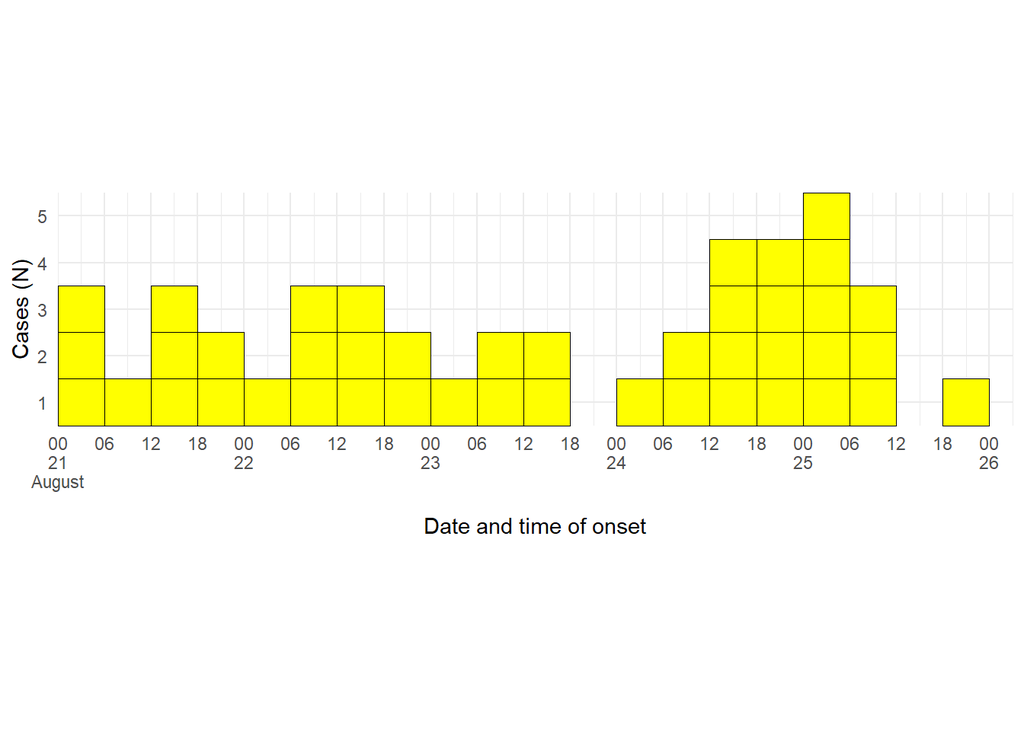

(a) *This data are simulated.*

Figure 1: Date and time of onset of diarrhoeal illness among cases. Wedding reception, Malahide, 21 August 1996

## Simulated Data

Table 6: Simulated “1996s wedding” data, used for the analyses on this report

| guest_id | wedding_cohort | eligible | interviewed | not_eaten | refused_to_participate | unable_to_locate | age_class | gender | illness | meals | date_of_illness | seating_arrangements |
| --- | --- | --- | --- | --- | --- | --- | --- | --- | --- | --- | --- | --- |
| 1 | TRUE | TRUE | TRUE | TRUE | FALSE | FALSE | 45 - 64 | Male | TRUE | Main meal only | 1996-08-24 00:00:00 | Table 3 |
| 2 | TRUE | TRUE | TRUE | TRUE | FALSE | FALSE | 15 - 44 | Female | FALSE | Late night meal only | 1996-08-22 12:00:00 | NA |
| 3 | TRUE | TRUE | TRUE | FALSE | FALSE | FALSE | 15 - 44 | Male | FALSE | Late night meal only | 1996-08-21 13:00:00 | NA |
| 4 | TRUE | TRUE | TRUE | FALSE | FALSE | FALSE | 15 - 44 | Male | FALSE | Late night meal only | 1996-08-22 06:00:00 | NA |
| 5 | TRUE | TRUE | TRUE | FALSE | FALSE | FALSE | 45 - 64 | Female | FALSE | Main meal only | 1996-08-21 22:00:00 | Table 6 |
| 6 | TRUE | TRUE | TRUE | FALSE | FALSE | FALSE | 15 - 44 | Male | FALSE | Main meal only | 1996-08-25 06:00:00 | Table 1 |
| 7 | TRUE | TRUE | TRUE | FALSE | FALSE | FALSE | 15 - 44 | Male | FALSE | Late night meal only | 1996-08-22 19:00:00 | NA |
| 8 | TRUE | TRUE | TRUE | FALSE | FALSE | FALSE | NA | Female | FALSE | Late night meal only | 1996-08-21 16:00:00 | NA |
| 9 | TRUE | TRUE | TRUE | TRUE | FALSE | FALSE | 15 - 44 | Male | FALSE | Late night meal only | 1996-08-21 19:00:00 | NA |
| 10 | TRUE | TRUE | TRUE | FALSE | FALSE | FALSE | 45 - 64 | Female | FALSE | Main meal only | 1996-08-21 23:00:00 | Table 7 |

[output cut: 117 more lines]

Table 7: Simulated “1996s wedding” clinical and laboratory data, used for the analyses on this report

| guest_id | diarrhoea | feeling_faverish | aches_and_pains | nausea | abdominal_cramps | vomiting | headaches | blood_seen_in_on_stool | gp_visit | hospitalization | stool_samples_obtained | stool_sample_plus_ve_for_salmonella_typhimurium | time_in_hospital | duration_of_illness | incubation_period |
| --- | --- | --- | --- | --- | --- | --- | --- | --- | --- | --- | --- | --- | --- | --- | --- |
| 1 | TRUE | FALSE | TRUE | FALSE | FALSE | FALSE | FALSE | FALSE | TRUE | FALSE | TRUE | TRUE | 9 | 306 | 37 |
| 13 | TRUE | TRUE | FALSE | TRUE | FALSE | TRUE | FALSE | FALSE | TRUE | FALSE | TRUE | TRUE | 246 | 181 | 49 |
| 15 | TRUE | TRUE | TRUE | TRUE | FALSE | TRUE | FALSE | FALSE | FALSE | FALSE | TRUE | TRUE | 296 | 308 | 48 |
| 16 | TRUE | TRUE | FALSE | FALSE | FALSE | TRUE | TRUE | FALSE | TRUE | FALSE | TRUE | TRUE | 262 | 165 | 71 |
| 21 | TRUE | FALSE | TRUE | FALSE | FALSE | FALSE | FALSE | FALSE | FALSE | FALSE | TRUE | TRUE | 120 | 252 | 47 |
| 22 | TRUE | TRUE | FALSE | TRUE | FALSE | TRUE | FALSE | FALSE | TRUE | FALSE | TRUE | TRUE | 287 | 297 | 26 |
| 34 | TRUE | FALSE | TRUE | FALSE | TRUE | FALSE | FALSE | FALSE | FALSE | FALSE | FALSE | FALSE | 7 | 197 | 63 |
| 36 | TRUE | FALSE | FALSE | FALSE | FALSE | FALSE | FALSE | FALSE | TRUE | FALSE | TRUE | FALSE | 71 | 218 | 63 |
| 38 | TRUE | TRUE | TRUE | FALSE | FALSE | FALSE | FALSE | FALSE | TRUE | FALSE | TRUE | FALSE | 274 | 4 | 22 |
| 44 | TRUE | TRUE | TRUE | FALSE | TRUE | FALSE | FALSE | FALSE | TRUE | FALSE | TRUE | TRUE | 292 | 168 | 42 |

[output cut: 33 more lines]